# Untitled

Guilherme Pazian

2 de novembro de 2016

**#Lista 2**

# Exercício 5

## Estatísticas descritivas

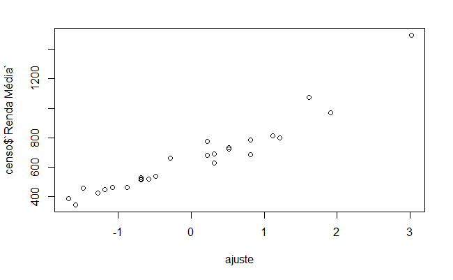

```r
ajuste <- censo$`Anos de Escolaridade` - mean(censo$`Anos de Escolaridade`)
plot(ajuste,censo$`Renda MÃ©dia`)
```

```r
a=sum(censo$`Renda MÃ©dia`)
b=sum((ajuste-mean(ajuste))^2)
beta_0 = mean(a*((1/nrow(censo))-mean(ajuste)*((ajuste-mean(ajuste))/b)))
beta_1= sum((censo$`Renda MÃ©dia`)*(ajuste-mean(ajuste))/b)
w_0 = (1/nrow(censo))+((mean(ajuste)^2)*b)
w_1 = 1/b
sigma2 =(sum((ajuste-beta_0-beta_1*censo$`Anos de Escolaridade`)^2))/(nrow(censo)-2)
t=qt(0.975,24)
ic_beta_0 = beta_0+c(-1,1)*t*sqrt(sigma2*w_0)
ic_beta_1 = beta_1+c(-1,1)*t*sqrt(sigma2*w_1)
t_0=beta_0/sqrt(sigma2*w_0)
t_1=beta_1/sqrt(sigma2*w_1)
t_0 > t
```

```
[1] FALSE
```

```r
t_1 > t
```

```
[1] FALSE
```

```r
(p_valor_beta_0_1=c(pt(t_0,24),pt(t_1,24)))
```

```
[1] 0.9637410 0.7437124
```

```r
(model <- lm((censo$`Renda MÃ©dia`)~ajuste))
```

```
Call:
lm(formula = (censo$`Renda MÃ©dia`) ~ ajuste)

Coefficients:
(Intercept)       ajuste
      657.5        200.9
```

```r
pred <- predict(model)
```

```r
plot(ajuste,censo$`Renda MÃ©dia`)
abline(model,col="red",lty = 3)
```

[figure not shown]

```r
par(mfrow=c(1,1))
```

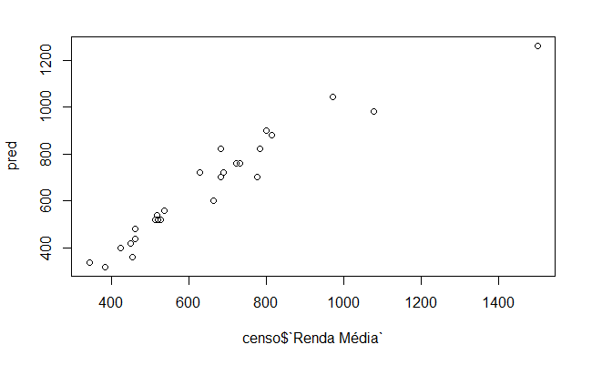

```r
plot(censo$`Renda MÃ©dia`,pred)
abline(model,col="red",lty = 3)
```

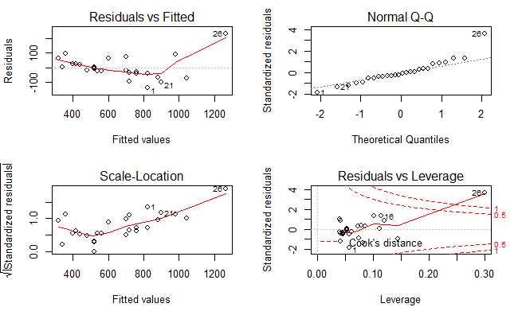

```r
par(mfrow=c(2,2))
plot(model)
```

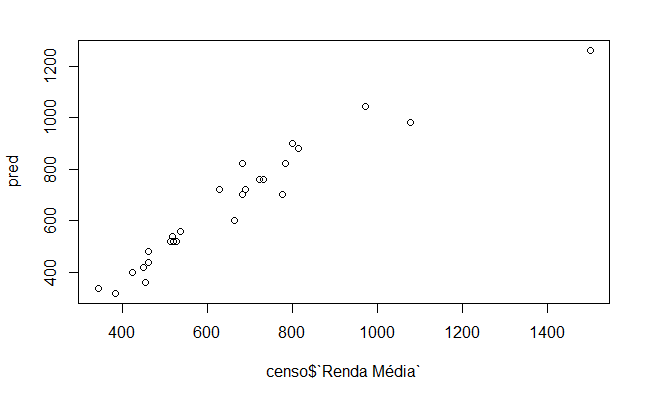

```r
par(mfrow=c(1,1))
plot(censo$`Renda MÃ©dia`,pred)
abline(model,col="red",lty = 3)
```

# Exercício 6

```r
imoveis = read.table("http://www.ime.unicamp.br/~cnaber/imoveis.txt")
names(imoveis)=c("Imposto","Ãrea_terreno","Ãrea_construÃda","Idade","Preco_venda")
```

```r
dif <- function(x){
  diff(range(x))
}
medias = as.numeric(lapply(imoveis,mean))
se = as.numeric(lapply(imoveis,sd))
quantis = lapply(imoveis,quantile)
ampli = lapply(imoveis,dif)
(estats_desc=data.frame(medias,se,quantis,ampli))
```

|  | medias | se | Imposto | Área_terreno | Área_construída | Idade | Preco_venda | Imposto.1 | Área_terreno.1 | Área_construída.1 | Idade.1 | Preco_venda.1 |
| --- | --- | --- | --- | --- | --- | --- | --- | --- | --- | --- | --- | --- |
| 0% | 7.244741 | 2.8821400 | 3.89100 | 2.27500 | 0.9750 | 3 | 25.90 | 11.5292 | 10.525 | 2.445 | 59 | 59 |
| 25% | 6.347556 | 2.4036766 | 5.18000 | 4.72165 | 1.1875 | 30 | 29.95 | 11.5292 | 10.525 | 2.445 | 59 | 59 |
| 50% | 1.512074 | 0.5582652 | 6.09310 | 5.85000 | 1.4880 | 40 | 36.90 | 11.5292 | 10.525 | 2.445 | 59 | 59 |
| 75% | 36.481481 | 14.0531145 | 8.30355 | 7.56310 | 1.6580 | 47 | 40.75 | 11.5292 | 10.525 | 2.445 | 59 | 59 |
| 100% | 38.500000 | 14.3075021 | 15.42020 | 12.80000 | 3.4200 | 62 | 84.90 | 11.5292 | 10.525 | 2.445 | 59 | 59 |

```r
x = matrix(data=c(rep(1,27),imoveis$Imposto,imoveis$Ãrea_terreno,imoveis$Ãrea_construÃda,imoveis$Idade),nrow=27,ncol=5)
imoveis$Ãrea_terreno
```

```
 [1]  3.4720  3.5310  2.2750  4.0500  4.4550  4.4550  5.8500  9.5200
 [9]  9.8000 12.8000  6.4350  4.9883  5.5200  6.6660  5.0000  5.1500
[17]  6.9020  7.1020  7.8000  5.5200  4.0000  9.8900  6.7265  9.1500
[25]  8.0000  7.3262  5.0000
```

## Na mão

```r
library(MASS)
x = matrix(data=c(rep(1,27),imoveis$Imposto,imoveis$Ãrea_terreno,imoveis$Ãrea_construÃda,imoveis$Idade),nrow=27,ncol=5)
psi = ginv(t(x)%*%x)
beta=ginv(t(x)%*%x)%*%t(x)%*%imoveis$Preco_venda
identidade=diag((nrow(imoveis)))
sigma2 = (1/(nrow(imoveis)-4))*(t(imoveis$Preco_venda)%*%(identidade-x%*%ginv(t(x)%*%x)%*%t(x))%*%imoveis$Preco_venda)
t = qt(0.975,(nrow(imoveis)-4))
ic = function(beta,x){
  psi = ginv(t(x)%*%x)
  ics= numeric(2*nrow(psi))
  j=1
  for(i in seq(1,10,2)){
  ics[i]=beta[j]-1*t*sqrt(sigma2*psi[j,j])
  ics[i+1]=beta[j]+1*t*sqrt(sigma2*psi[j,j])
  j=j+1
  }
  return(ics)
}
teste = function(beta){
        ts= numeric(nrow(psi))

        for(i in 1:nrow(psi)){


           ts[i]=beta/sqrt(as.numeric(sigma2*(psi[i,i])))

         }
        return(ts)
}
tes = teste(beta)
```

[output not shown]

```r
tes < t
```

```
[1]  TRUE FALSE FALSE  TRUE FALSE
```

## Código em R

```r
(modelo <- lm(Preco_venda~Imposto+Ãrea_terreno+Ãrea_construÃda+Idade,data=imoveis))
```

```
Call:
lm(formula = Preco_venda ~ Imposto + Ãrea_terreno + Ãrea_construÃda +
    Idade, data = imoveis)

Coefficients:
    (Intercept)          Imposto     Ãrea_terreno  Ãrea_construÃda
        2.43587          2.07823          0.23238         13.97381
          Idade
       -0.04376
```

```
usando somente os dois primeiros de 5 coeficientes de regressão
```

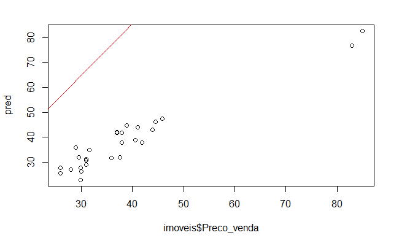

```r
pred = predict(modelo)
plot(imoveis$Preco_venda,pred)
abline(modelo,col="red")
```

**#Lista 3**

# Exercício 3

```r
#leitura dos dados
censo = read.table("http://www.ime.unicamp.br/~cnaber/censo.txt")
names(censo)=c("Estado","Anos_escolaridade","Renda_media")
```

### Análise descritiva

#### Gráfico

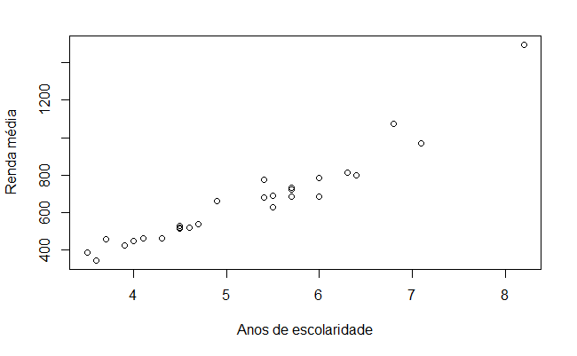

```r
plot(censo$Anos_escolaridade,censo$Renda_media,xlab="Anos de escolaridade",ylab="Renda mÃ©dia")
```

### Modelos

Dada a natureza dos dados, como vista no gráfico acima, proporá-se dois modelos, um linear e outro quadrado

#### Modelo 1 (Linear)

$$y_{i}=\beta_{0}+\beta_{1}x_{i}+e_{i}$$

##### Ajuste

```r
modelo1 = lm(censo$Renda_media~censo$Anos_escolaridade)
summary(modelo1)
```

```
Call:
lm(formula = censo$Renda_media ~ censo$Anos_escolaridade)

Residuals:
    Min      1Q  Median      3Q     Max
-134.68  -35.70  -15.97   27.47  241.70

Coefficients:
                        Estimate Std. Error t value Pr(>|t|)
(Intercept)              -381.28      69.40  -5.494 1.05e-05 ***
censo$Anos_escolaridade   199.83      13.03  15.338 3.17e-14 ***
---
Signif. codes:  0 â€˜***â€™ 0.001 â€˜**â€™ 0.01 â€˜*â€™ 0.05 â€˜.â€™ 0.1 â€˜ â€™ 1

Residual standard error: 77.22 on 25 degrees of freedom
Multiple R-squared:  0.9039,    Adjusted R-squared:  0.9001
F-statistic: 235.3 on 1 and 25 DF,  p-value: 3.167e-14
```

##### Análise Residual

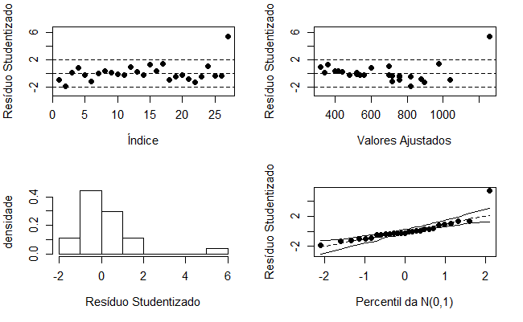

```r
diagnorm(modelo1)
```

1. Presença de Heterocedasticidade (Vista no gráfico Valores Ajustados x Resíduos Studentalizados)
2. Possível não normalidade dos dados (Vista no gráfico Resíduo Studentalizado x densidade)

#### Modelo 2 (Quadrado)

$$y_{i}=\beta_{0}+\beta_{1}x_{i}+\beta_{2}x_{i}^{2}+e_{i}$$

**Ajuste**

```r
a2 = (censo$Anos_escolaridade)^2
modelo2=lm(censo$Renda_media~censo$Anos_escolaridade+a2)
summary(modelo2)
```

```
Call:
lm(formula = censo$Renda_media ~ censo$Anos_escolaridade + a2)

Residuals:
     Min       1Q   Median       3Q      Max
-102.264  -24.890    1.764   18.257  121.497

Coefficients:
                        Estimate Std. Error t value Pr(>|t|)
(Intercept)              546.982    196.802   2.779   0.0104 *
censo$Anos_escolaridade -152.620     72.863  -2.095   0.0469 *
a2                        31.916      6.543   4.878 5.66e-05 ***
---
Signif. codes:  0 â€˜***â€™ 0.001 â€˜**â€™ 0.01 â€˜*â€™ 0.05 â€˜.â€™ 0.1 â€˜ â€™ 1

Residual standard error: 55.85 on 24 degrees of freedom
Multiple R-squared:  0.9518,    Adjusted R-squared:  0.9477
F-statistic: 236.8 on 2 and 24 DF,  p-value: < 2.2e-16
```

**Análise Residual**:

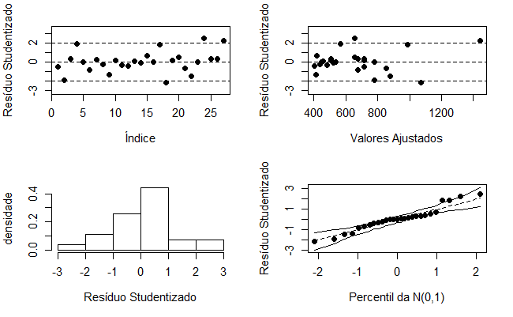

```r
diagnorm(modelo2)
```

1. Presença de Heterocedasticidade (Vista no gráfico Valores Ajustados x Resíduos Studentalizados)
2. Possível não normalidade dos dados (Vista no gráfico Resíduo Studentalizado x densidade)

```r
library(printr)
estat_test =  data.frame(rbind(AIC(modelo1),BIC(modelo1),logLik(modelo1)),rbind(AIC(modelo2),BIC(modelo2),logLik(modelo2)))
rownames(estat_test)=c("AIC","BIC","Log-Verosi")
colnames(estat_test)=c("Modelo1","Modelo2")
estat_test
```

|  | Modelo1 | Modelo2 |
| --- | --- | --- |
| AIC | 315.2632 | 298.6633 |
| BIC | 319.1507 | 303.8466 |
| Log-Verosi | -154.6316 | -145.3316 |

Pelas análises de **AIC** e do **BIC**, observa-se que o segundo modelo proposto é o melhor a se utilizado pois os valores das estastísticas são menores(Quanto menor, melhor).

# Exercício 4

# Exercício 5

## Análise Descritiva

### Gráficos

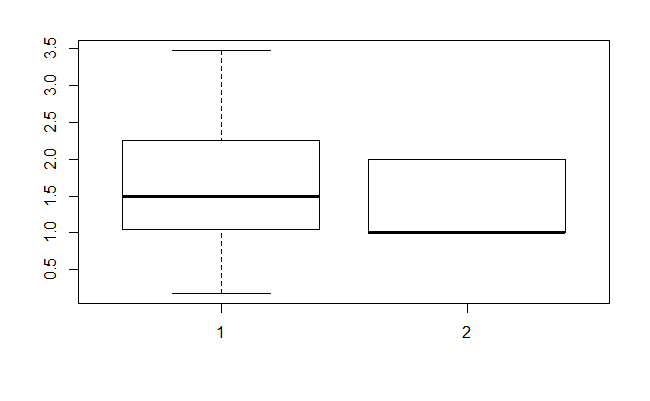

```r
boxplot(dados_escova$`IPB_prÃ©-escovaÃ§Ã£o_escova_Hugger`,dados_escova$sexo)
```

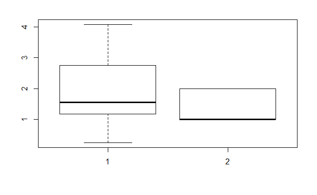

```r
boxplot(dados_escova$`IPB_prÃ©-escovaÃ§Ã£o_escova_tradicional`,dados_escova$sexo)
```

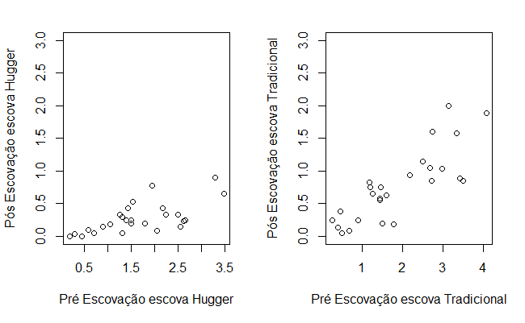

## Ajuste do Modelo em R

### Ajuste do modelo completo

#### Modelo

$$y_{ijk}=\beta_{0ij}+\beta_{1ij}x_{ijk}+\varepsilon_{ijk}$$

$\beta_{0ij}$:Valor Esperado quando a quantidade de placa for igual a zero($x_{ijk}$=0)

$\beta_{1ij}$:Incremento(+/-) quanto se aumenta uma unidade da variável explicativa

$x_{ijk}$: individuo k que escovou com a escova j e é do sexo i

$\varepsilon_{ijk}$:erro amostral

$\varepsilon_{ijk}\sim \mathit{N}(0,\sigma ^{2})$

```r
result_compl <- lm(ipbpos~-1+sexotescf+(ipbpre:sexotescf))
summary(result_compl)
```

```
Call:
lm(formula = ipbpos ~ -1 + sexotescf + (ipbpre:sexotescf))

Residuals:
     Min       1Q   Median       3Q      Max
-0.57122 -0.12042 -0.00263  0.16182  0.75873

Coefficients:
                               Estimate Std. Error t value Pr(>|t|)
sexotescfF.Convencional         0.03224    0.12565   0.257  0.79869
sexotescfM.Convencional        -0.37832    0.22703  -1.666  0.10274
sexotescfF.Hugger              -0.06223    0.12919  -0.482  0.63240
sexotescfM.Hugger               0.06545    0.18508   0.354  0.72531
sexotescfF.Convencional:ipbpre  0.44494    0.08482   5.246 4.26e-06
sexotescfM.Convencional:ipbpre  0.51415    0.08126   6.327 1.11e-07
sexotescfF.Hugger:ipbpre        0.22855    0.07650   2.988  0.00458
sexotescfM.Hugger:ipbpre        0.11725    0.09098   1.289  0.20421

sexotescfF.Convencional
sexotescfM.Convencional
sexotescfF.Hugger
sexotescfM.Hugger
sexotescfF.Convencional:ipbpre ***
sexotescfM.Convencional:ipbpre ***
sexotescfF.Hugger:ipbpre       **
sexotescfM.Hugger:ipbpre
---
Signif. codes:  0 â€˜***â€™ 0.001 â€˜**â€™ 0.01 â€˜*â€™ 0.05 â€˜.â€™ 0.1 â€˜ â€™ 1

Residual standard error: 0.2506 on 44 degrees of freedom
Multiple R-squared:  0.8943,    Adjusted R-squared:  0.875
F-statistic: 46.51 on 8 and 44 DF,  p-value: < 2.2e-16
```

Pode-se observar que os interceptos das retas não são significativos, ou seja, a redução de placa é esta´tisticamente igual para índice da placa igual a 0.

Para os coeficientes angulares nota-se que para os casos aonde se escova com a escova convencional, independentemente do sexo e quando as meninas escovam com a escova Hugger que o valor do intercepto é “alto”, ou seja, não houve uma redução drástica de placas quanto houve no caso em que os meninos escovaram com a Hugger.

**Matriz de planejamento**

|  | ConvencionalF | ConvencionalM | HuggerF | HuggerM | ipbpreConvF | ipbpreConvm | ipbpreHuggerF | ipbprehuggerM |
| --- | --- | --- | --- | --- | --- | --- | --- | --- |
| 1 | 1 | 0 | 0 | 0 | 1.20 | 0.00 | 0.00 | 0.00 |
| 2 | 1 | 0 | 0 | 0 | 1.43 | 0.00 | 0.00 | 0.00 |
| 3 | 1 | 0 | 0 | 0 | 0.68 | 0.00 | 0.00 | 0.00 |
| 4 | 1 | 0 | 0 | 0 | 1.45 | 0.00 | 0.00 | 0.00 |
| 5 | 1 | 0 | 0 | 0 | 0.50 | 0.00 | 0.00 | 0.00 |
| 6 | 1 | 0 | 0 | 0 | 2.75 | 0.00 | 0.00 | 0.00 |
| 7 | 1 | 0 | 0 | 0 | 1.25 | 0.00 | 0.00 | 0.00 |
| 8 | 1 | 0 | 0 | 0 | 0.40 | 0.00 | 0.00 | 0.00 |
| 9 | 1 | 0 | 0 | 0 | 1.18 | 0.00 | 0.00 | 0.00 |
| 10 | 1 | 0 | 0 | 0 | 1.43 | 0.00 | 0.00 | 0.00 |

[output cut: 42 more lines]

#### Diagnóstico

##### Gráfico

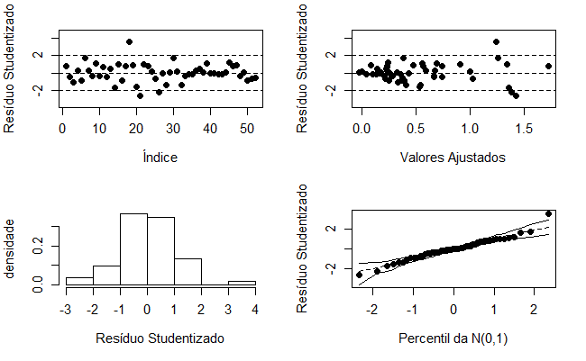

```r
diagnorm(result_compl)
```

Pela análise residual nota-se que há indicios de heterocedasticidade nos dados. QUanto as suposições de normalidade e independência parecem mais compatíveis com os gráficos apresentados.

#### Teste

Consideremos a seguinte hipótese:

Utilizaremos o teste $C\beta=0$ com:

$$C=\begin{bmatrix}
1 & -1 & 0 & 0 & 0 & 0 & 0 & 0\\
1 & 0 & -1 & 0 & 0 & 0 & 0 & 0\\
1 & 0 & 0 & -1 & 0 & 0 & 0 & 0
\end{bmatrix}$$

```r
c=t(matrix(c(1,-1,0,0,0,0,0,0,1,0,-1,0,0,0,0,0,1,0,0,-1,0,0,0,0),8,3))
testeF.CB(result_compl,c)
```

```
Estatistica F =  0.97
pvalor =  0.4162
Matriz C :
     [,1] [,2] [,3] [,4] [,5] [,6] [,7] [,8]
[1,]    1   -1    0    0    0    0    0    0
[2,]    1    0   -1    0    0    0    0    0
[3,]    1    0    0   -1    0    0    0    0
```

### Ajustando um modelo sem intercepto

Dada a natureza do problema, pode-se imaginar um modelo sem intercepto pois quando o indice pré-escovação é zero espera que pós-escovação também o seja.

Logo, seja o modelo(ainda considerando o sexo):

$$y_{ijk}=\beta_{1ij}x_{ijk}+\varepsilon_{ijk}$$

$\beta_{1ij}$:Incremento(+/-) quanto se aumenta uma unidade da variável explicativa

$x_{ijk}$: individuo k que escovou com a escova j e é do sexo i

$\varepsilon_{ijk}$:erro amostral

$\varepsilon_{ijk}\sim \mathit{N}(0,\sigma ^{2})$

```r
result_s_i <- lm(ipbpos~-1+(ipbpre:sexotescf))
summary(result_s_i)
```

```
Call:
lm(formula = ipbpos ~ -1 + (ipbpre:sexotescf))

Residuals:
     Min       1Q   Median       3Q      Max
-0.50673 -0.11924 -0.02603  0.13535  0.78472

Coefficients:
                               Estimate Std. Error t value Pr(>|t|)
ipbpre:sexotescfF.Convencional  0.46335    0.04482  10.337 8.45e-14
ipbpre:sexotescfM.Convencional  0.38580    0.02567  15.028  < 2e-16
ipbpre:sexotescfF.Hugger        0.19704    0.03932   5.011 7.76e-06
ipbpre:sexotescfM.Hugger        0.14686    0.03526   4.165 0.000129

ipbpre:sexotescfF.Convencional ***
ipbpre:sexotescfM.Convencional ***
ipbpre:sexotescfF.Hugger       ***
ipbpre:sexotescfM.Hugger       ***
---
Signif. codes:  0 â€˜***â€™ 0.001 â€˜**â€™ 0.01 â€˜*â€™ 0.05 â€˜.â€™ 0.1 â€˜ â€™ 1

Residual standard error: 0.2485 on 48 degrees of freedom
Multiple R-squared:  0.8866,    Adjusted R-squared:  0.8771
F-statistic: 93.79 on 4 and 48 DF,  p-value: < 2.2e-16
```

Observa-se que o desempenho das escovas Hugger são melhores comparados aos da convencional, inpedentemente do sexo.

Obviamente, nota-se uma diminuição do indice de placas mas é natural dada a natureza do experimento pois quando se escova o dente razoavelmente bem, é natural que haja diminuição das placas.

**Matriz de planejamento**

|  | ipbpre.sexotescfF.Convencional | ipbpre.sexotescfM.Convencional | ipbpre.sexotescfF.Hugger | ipbpre.sexotescfM.Hugger |
| --- | --- | --- | --- | --- |
| 1 | 1.20 | 0.00 | 0.00 | 0.00 |
| 2 | 1.43 | 0.00 | 0.00 | 0.00 |
| 3 | 0.68 | 0.00 | 0.00 | 0.00 |
| 4 | 1.45 | 0.00 | 0.00 | 0.00 |
| 5 | 0.50 | 0.00 | 0.00 | 0.00 |
| 6 | 2.75 | 0.00 | 0.00 | 0.00 |
| 7 | 1.25 | 0.00 | 0.00 | 0.00 |
| 8 | 0.40 | 0.00 | 0.00 | 0.00 |
| 9 | 1.18 | 0.00 | 0.00 | 0.00 |
| 10 | 1.43 | 0.00 | 0.00 | 0.00 |

[output cut: 42 more lines]

#### Diagnóstico

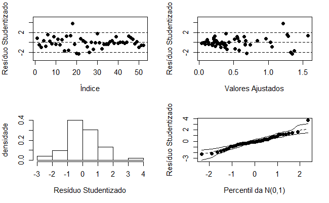

```r
diagnorm(result_s_i)
```

Vemos que hápresença de heterocedasticidade.

#### Testes

C=
$$\begin{bmatrix}
1 & -1 & 0 & 0\\
1 & 0 & -1 & 0\\
1 & 0 & 0 & -1
\end{bmatrix}$$

```r
(c=t(matrix(c(1,-1,0,0,1,0,-1,0,1,0,0,-1),4,3)))
```

```
     [,1] [,2] [,3] [,4]
[1,]    1   -1    0    0
[2,]    1    0   -1    0
[3,]    1    0    0   -1
```

```r
testeF.CB(result_s_i,c)
```

```
Estatistica F =  16.68
pvalor =  0
Matriz C :
     [,1] [,2] [,3] [,4]
[1,]    1   -1    0    0
[2,]    1    0   -1    0
[3,]    1    0    0   -1
```

#### Ajustando um modelo reduzido, desconsiderando o sexo

Dada a análise anterior, façamos um modelo que desconsiderará o sexo como fator de análise.

**Modelo** :

$$y_{ij}=\beta_{0i}+\beta_{1i}x_{ij}+\varepsilon_{ij}$$

$\beta_{0i}$:Valor Esperado quando a quantidade de placa for igual a zero($x_{ij}$=0).

$\beta_{1i}$:Incremento(+/-) quanto se aumenta uma unidade da variável explicativa.

$x_{ij}$: individuo j que escovou com a escova i.

$\varepsilon_{ij}$:erro amostral.

$\varepsilon_{ij}\sim \mathit{N}(0,\sigma ^{2})$

```r
result <- lm(ipbpos~-1+tescf+ipbpre:tescf)
summary(result)
```

```
Call:
lm(formula = ipbpos ~ -1 + tescf + ipbpre:tescf)

Residuals:
     Min       1Q   Median       3Q      Max
-0.56233 -0.13281 -0.00688  0.13732  0.72761

Coefficients:
                          Estimate Std. Error t value Pr(>|t|)
tescfConvencional         0.012959   0.101063   0.128  0.89851
tescfHugger              -0.009596   0.107802  -0.089  0.92944
tescfConvencional:ipbpre  0.399819   0.046203   8.654 2.31e-11 ***
tescfHugger:ipbpre        0.173799   0.058074   2.993  0.00436 **
---
Signif. codes:  0 â€˜***â€™ 0.001 â€˜**â€™ 0.01 â€˜*â€™ 0.05 â€˜.â€™ 0.1 â€˜ â€™ 1

Residual standard error: 0.2564 on 48 degrees of freedom
Multiple R-squared:  0.8792,    Adjusted R-squared:  0.8691
F-statistic: 87.32 on 4 and 48 DF,  p-value: < 2.2e-16
```

Observa-se que os interceptos parecem ser nulos e os coeficientes angulares sugerem uma superioridade da escova Hugger(quanto menor, melhor).

##### Gráfico

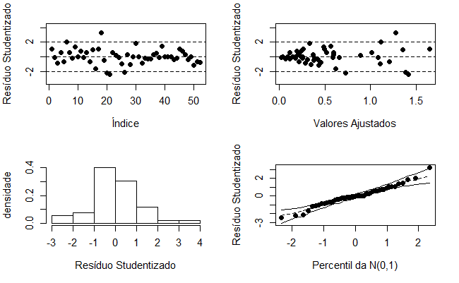

```r
diagnorm(result)
```

Dados os gráficos apresentados acima, observa-se que as suposições homocedasticidade e normalidade não são atendidas pois observa-se no uma tendência em forma de funil no gráfico de Valores Ajustados x Resíduos Studentizados, indicando oscilação de variãncia. No gráfico de Resíduos Studentizados x densidade, observa-se uma leve assimetria dos dados.

Pode-se resolver o problema, modelando os erros por alguma distribuição assimétrica, ou talvez, mesmo por uma Distribuição Normal Heterocedástica.

##### Teste

Consideremos a seguinte hipótese:

Utilizaremos o teste $C\beta=0$ com

$$C=\begin{bmatrix}
1 & -1 & 0 & 0 & \\
\end{bmatrix}$$

```r
(c=t(matrix(c(1,-1,0,0),4,1)))
```

```
     [,1] [,2] [,3] [,4]
[1,]    1   -1    0    0
```

```r
testeF.CB(result,c)
```

```
Estatistica F =  0.02
pvalor =  0.8793
Matriz C :
     [,1] [,2] [,3] [,4]
[1,]    1   -1    0    0
```

##### Modelos sem intercepto

```r
result_0 <- lm(ipbpos~-1+ipbpre:tescf)
summary(result_0)
```

```
Call:
lm(formula = ipbpos ~ -1 + ipbpre:tescf)

Residuals:
     Min       1Q   Median       3Q      Max
-0.56735 -0.12397 -0.01061  0.14504  0.72438

Coefficients:
                         Estimate Std. Error t value Pr(>|t|)
ipbpre:tescfConvencional  0.40496    0.02253  17.972  < 2e-16 ***
ipbpre:tescfHugger        0.16923    0.02655   6.373 5.73e-08 ***
---
Signif. codes:  0 â€˜***â€™ 0.001 â€˜**â€™ 0.01 â€˜*â€™ 0.05 â€˜.â€™ 0.1 â€˜ â€™ 1

Residual standard error: 0.2513 on 50 degrees of freedom
Multiple R-squared:  0.8791,    Adjusted R-squared:  0.8743
F-statistic: 181.8 on 2 and 50 DF,  p-value: < 2.2e-16
```

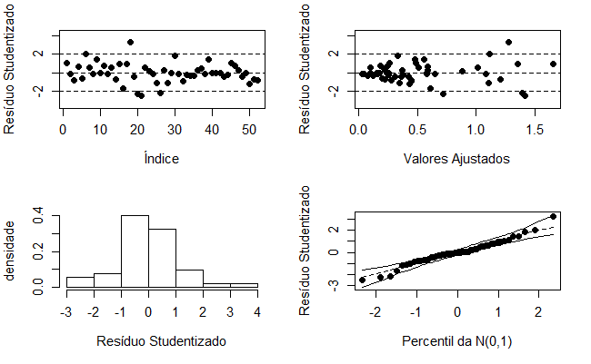

```r
diagnorm(result_0)
```

Presença de Heterocedasticidade

##### Testes

```r
(c=t(matrix(c(1,-1),2,1)))
```

```
     [,1] [,2]
[1,]    1   -1
```

```r
testeF.CB(result_0,c)
```

```
Estatistica F =  45.82
pvalor =  0
Matriz C :
     [,1] [,2]
[1,]    1   -1
```

Para estimarmos o ganho do melhor tipo de escova, usaremos o método Delta.

```r
ganho=round(((summary(result_0)$coefficients)[2]/(summary(result_0)$coefficients)[1])*100,1)
```

Ganho obtido: `41.8%.

# Exercício 6

### Análise Descritiva

| Grupo | Media | Dia | Media |
| --- | --- | --- | --- |
| G1 | 26.93750 | 1 | 29.5000 |
| G2 | 34.96875 | 2 | 29.3125 |
| G3 | 29.12500 | 3 | 27.6250 |
| G4 | 25.46875 | 4 | 30.0625 |

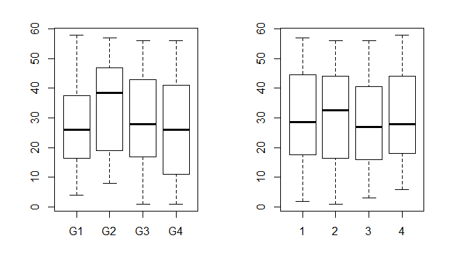

```r
par(mfrow=c(1,2))
boxplot(Antes~factor(Grupo),data=mydata3)
boxplot(Antes~factor(Dia),data=mydata3)
```

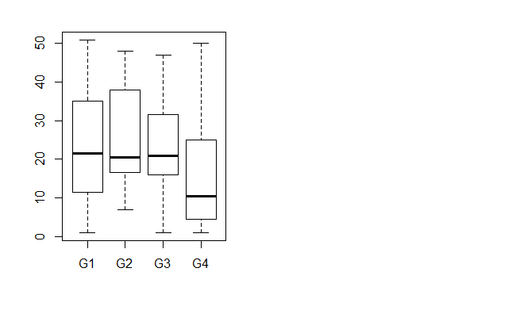

```r
boxplot(Depois~factor(Grupo),data=mydata3)
```

O Boxplot mostra que “antes” não haviam diferenças significativas entre os grupos e também relacionadamente aos dias.

### Ajuste do modelo com intercepto, desconsiderando o dia.

#### Modelo

$$y_{ij}=\beta_{0i}+\beta_{1i}x_{ij}+e_{ij}$$

$\beta_{0i}$ = valor esperado quando o valor do IPB antes é igual a zero.

$\beta_{1i}$ = incremento (+/-) quando se aumenta o valor de $x_{ij}$ em uma unidade.

```r
results = lm((Depois) ~ -1+Grupo + Antes:Grupo, mydata3)
summary(results)
```

```
Call:
lm(formula = (Depois) ~ -1 + Grupo + Antes:Grupo, data = mydata3)

Residuals:
    Min      1Q  Median      3Q     Max
-19.245  -4.530   1.087   4.403  13.835

Coefficients:
              Estimate Std. Error t value Pr(>|t|)
GrupoG1       -0.41098    2.66788  -0.154    0.878
GrupoG2        2.73490    3.10333   0.881    0.380
GrupoG3        5.38077    2.61743   2.056    0.042 *
GrupoG4       -3.81967    2.39229  -1.597    0.113
GrupoG1:Antes  0.88417    0.08753  10.102  < 2e-16 ***
GrupoG2:Antes  0.64744    0.08125   7.969 1.04e-12 ***
GrupoG3:Antes  0.61461    0.07899   7.781 2.80e-12 ***
GrupoG4:Antes  0.77329    0.08013   9.651  < 2e-16 ***
---
Signif. codes:  0 â€˜***â€™ 0.001 â€˜**â€™ 0.01 â€˜*â€™ 0.05 â€˜.â€™ 0.1 â€˜ â€™ 1

Residual standard error: 7.062 on 120 degrees of freedom
Multiple R-squared:   0.93, Adjusted R-squared:  0.9253
F-statistic: 199.2 on 8 and 120 DF,  p-value: < 2.2e-16
```

Conclui-se também que os grupos 2 e 3 tiveram maior redução em suas taxas que os outros grupos.

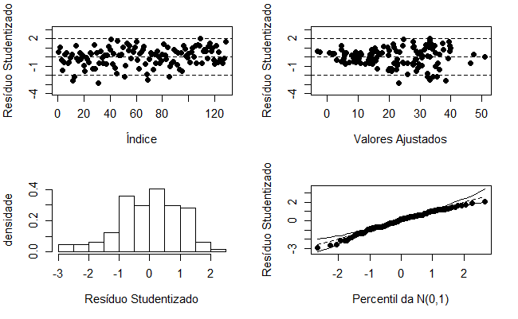

```r
diagnorm(results)
```

Os gráficos indicam a presença de heterocedasticidade. Uma leve assimetria negativa é notada pois o gráfico de resíduso studentizados x densidade apontam para uma leve concentração de dados “à direita” do centro.

#### Testes

Consideremos a seguinte hipótese:

Utilizaremos o teste $C\beta=0$ com
$$C=\begin{bmatrix}
1 & -1 & 0 & 0 & 0 & 0 & 0 & 0\\
1 & 0 & -1 & 0 & 0 & 0 & 0 & 0\\
1 & 0 & 0 & -1 & 0 & 0 & 0 & 0
\end{bmatrix}$$

```r
(c=t(matrix(c(1,-1,0,0,0,0,0,0,1,0,-1,0,0,0,0,0,1,0,0,-1,0,0,0,0),8,3)))
```

```
     [,1] [,2] [,3] [,4] [,5] [,6] [,7] [,8]
[1,]    1   -1    0    0    0    0    0    0
[2,]    1    0   -1    0    0    0    0    0
[3,]    1    0    0   -1    0    0    0    0
```

```r
testeF.CB(results,c)
```

```
Estatistica F =  2.46
pvalor =  0.0664
Matriz C :
     [,1] [,2] [,3] [,4] [,5] [,6] [,7] [,8]
[1,]    1   -1    0    0    0    0    0    0
[2,]    1    0   -1    0    0    0    0    0
[3,]    1    0    0   -1    0    0    0    0
```

### Ajustando Modelo sem intercepto

```r
results1 = lm((Depois) ~ -1+Antes, mydata3)
summary(results1)
```

```
Call:
lm(formula = (Depois) ~ -1 + Antes, data = mydata3)

Residuals:
     Min       1Q   Median       3Q      Max
-22.1789  -4.4208   0.9309   6.1158  12.5772

Coefficients:
      Estimate Std. Error t value Pr(>|t|)
Antes  0.74797    0.01995   37.49   <2e-16 ***
---
Signif. codes:  0 â€˜***â€™ 0.001 â€˜**â€™ 0.01 â€˜*â€™ 0.05 â€˜.â€™ 0.1 â€˜ â€™ 1

Residual standard error: 7.468 on 127 degrees of freedom
Multiple R-squared:  0.9171,    Adjusted R-squared:  0.9165
F-statistic:  1405 on 1 and 127 DF,  p-value: < 2.2e-16
```

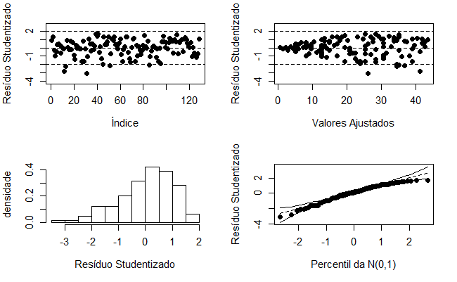

```r
diagnorm(results1)
```